# IE360 HW3

Emirhan Esen

06 06 2021

## Data preperation

In this part, I made data importing and some manipulations. After read data as a csv file, “Tarih” column is converted from chracter to date class. Also, “Tüketim” columns is converted to numeric class and renamed.

```r
consumptiondata=fread('Tuketim.csv')
#str(consumptiondata)
setnames(consumptiondata,3 , "Consumption")



consumptiondata[,Consumption:=as.numeric(gsub(",", "", Consumption))]
head(consumptiondata)
```

```
##         Tarih  Saat Consumption
## 1: 01.01.2016 00:00    26.27724
## 2: 01.01.2016 01:00    24.99182
## 3: 01.01.2016 02:00    23.53261
## 4: 01.01.2016 03:00    22.46478
## 5: 01.01.2016 04:00    22.00291
## 6: 01.01.2016 05:00    21.95708
```

```r
consumptiondata[,Consumption := 1000*Consumption]
consumptiondata[,datetime:=paste(Tarih,Saat)]

consumptiondata[,datetime:=as.POSIXct(datetime, format= "%d.%m.%Y %H:%M" ,tz="UTC")]

head(consumptiondata$datetime)
```

```
## [1] "2016-01-01 00:00:00 UTC" "2016-01-01 01:00:00 UTC"
## [3] "2016-01-01 02:00:00 UTC" "2016-01-01 03:00:00 UTC"
## [5] "2016-01-01 04:00:00 UTC" "2016-01-01 05:00:00 UTC"
```

In order to take an overall idea and improve a better model, let make a fast look at the time series data plot. Then check the stationary of data, visualization show that data is not stationary. As expected, “Value of test-statistic is: 12.695” is greater than the all critical values so for now data is not stationary.

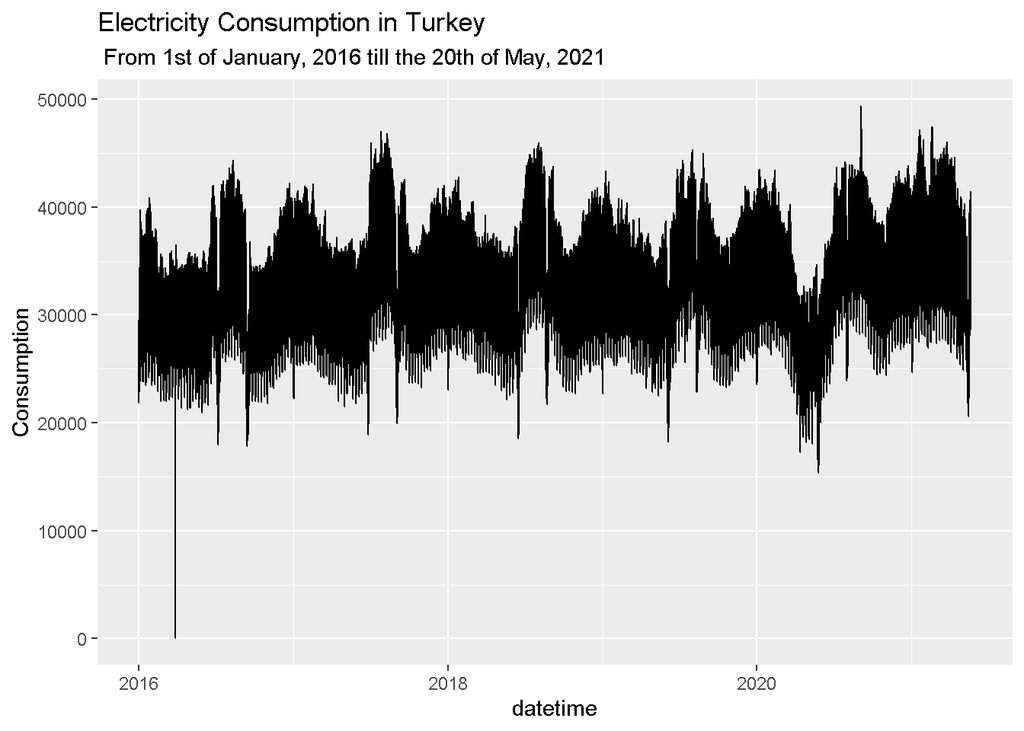

```r
ggplot(data=consumptiondata,aes(x=datetime,y=Consumption)) + geom_line(col = "black") + labs(title = "Electricity Consumption in Turkey", subtitle = " From 1st of January, 2016 till the 20th of May, 2021")
```

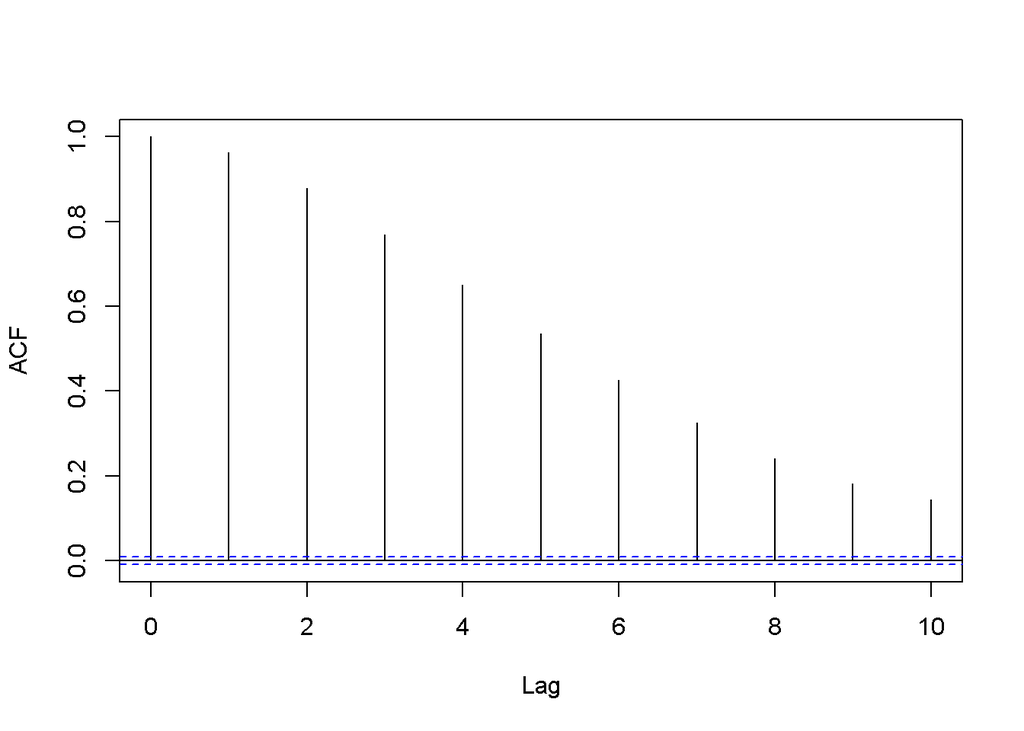

```r
plot(acf(consumptiondata$Consumption, lag.max = 10,plot=FALSE),main=" ", xlab="Lag")
```

```r
test=ur.kpss(consumptiondata$Consumption)
summary(test)
```

```
##
## #######################
## # KPSS Unit Root Test #
## #######################
##
## Test is of type: mu with 18 lags.
##
## Value of test-statistic is: 12.695
##
## Critical value for a significance level of:
##                 10pct  5pct 2.5pct  1pct
## critical values 0.347 0.463  0.574 0.739
```

## Decomposition of Data

In this part I try to find possible types of seasonality exhibited by hourly electricity consumption. For that purpose, I made decomposition for the consumption series at different levels which are hourly, daily and monthly levels.

# Hourly Decomposition

To hourly decomposition I need to create a time series object with a frequency value of 24. In this way, I can see whether there is a pattern in hours of a day.

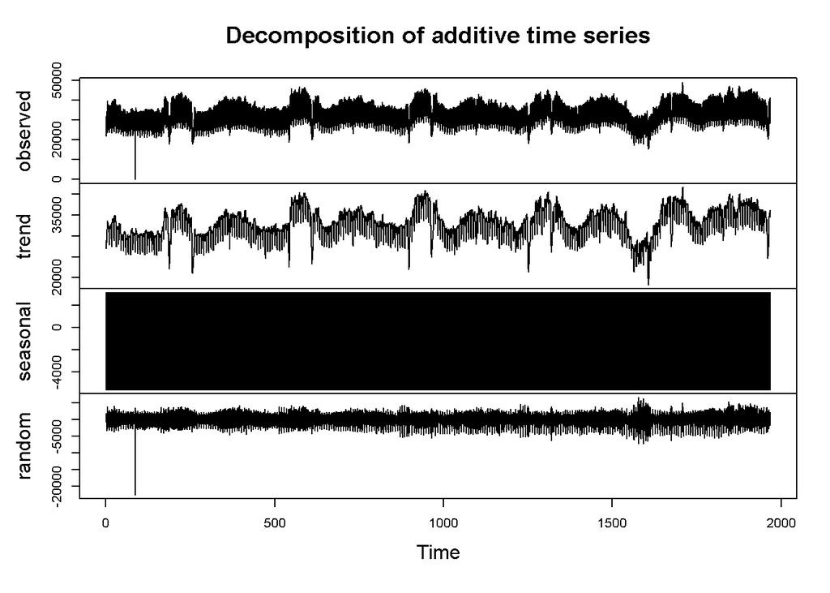

```r
consumptionts_hr=ts(consumptiondata$Consumption,frequency = 24)

consumptionts_hr_dec=decompose(consumptionts_hr)
plot(consumptionts_hr_dec)
```

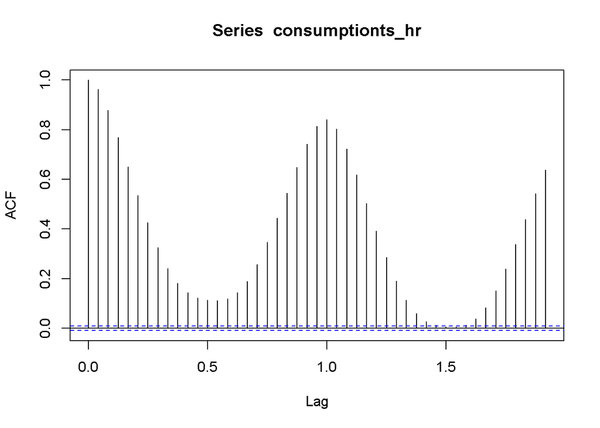

```r
acf(consumptionts_hr,na.action=na.pass)
```

As we can see there is a rapid seasonality in daily data and the variance seems stable. Also ACF shows that there is a seasonality effect. We should move to daily level.

# Daily Decomposition

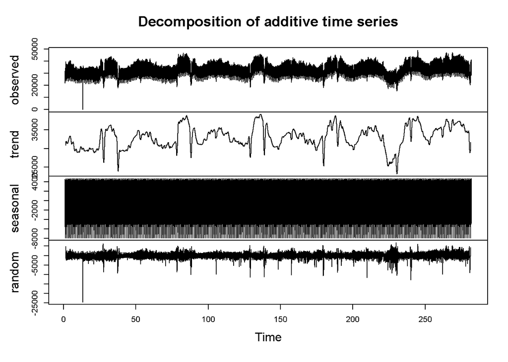

```r
consumptionts_dy=ts(consumptiondata$Consumption,frequency = 24*7)

consumptionts_dy_dec=decompose(consumptionts_dy)
plot(consumptionts_dy_dec)
```

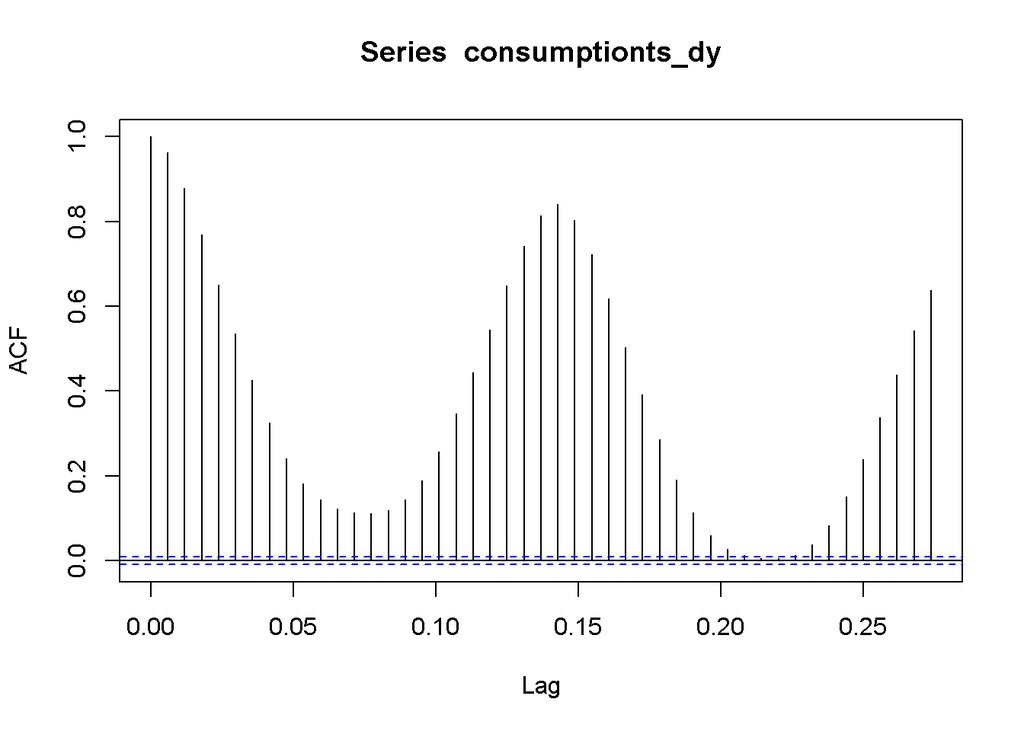

```r
acf(consumptionts_dy,na.action=na.pass)
```

To daily decomposition I need to create a time series object with a frequency value of 24*7. Try to determine there is a 7 days pattern or not. Both the hours and the days define the seasonality which is more sense.

# Monthly Decomposition

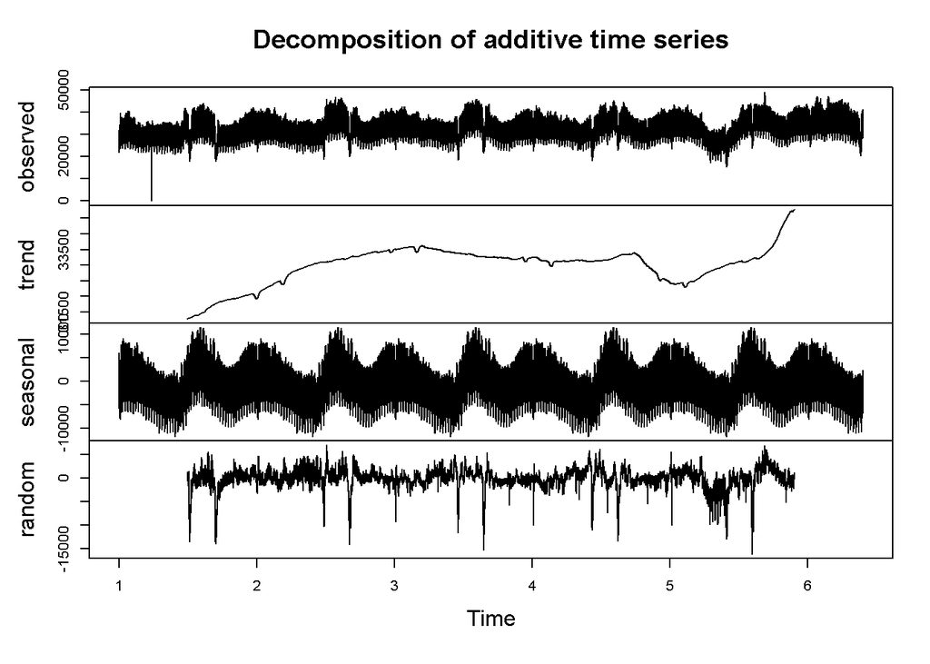

```r
consumptionts_mo=ts(consumptiondata$Consumption,frequency = 24*7*52)

consumptionts_mo_dec=decompose(consumptionts_mo)
plot(consumptionts_mo_dec)
```

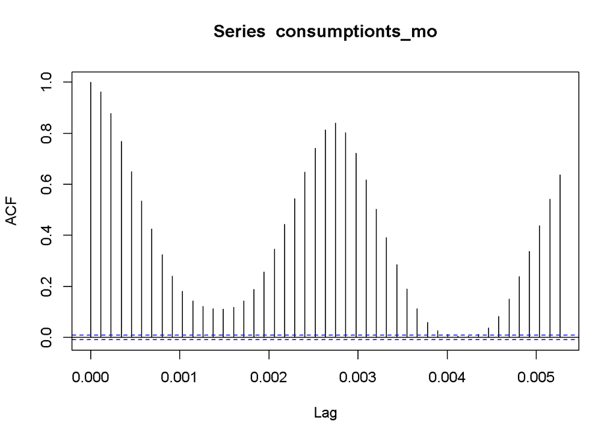

```r
acf(consumptionts_mo,na.action=na.pass)
```

To monthly decomposition I need to create a time series object with a frequency value of 24*7*52. Try to determine there is a 12 months pattern or not. Both the hours, days and months define the seasonality.

## Decomposition of Daily Data

Let’s choose the decomposed data which frequency is 168. Again, it means that both the hour and the day of the observation define the seasonality. I decompose this data by using “decompose()” function. It gives automatically trend and seasonality cycle for given frequency.

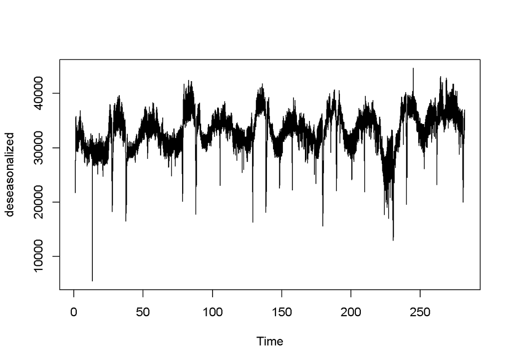

```r
deseasonalized=consumptionts_dy_dec$x- consumptionts_dy_dec$seasonal
plot(deseasonalized)
```

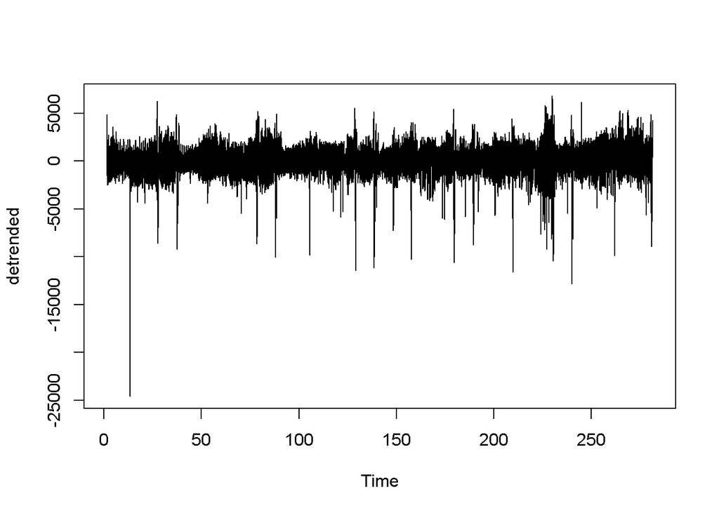

```r
detrended = deseasonalized-consumptionts_dy_dec$trend
plot(detrended)
```

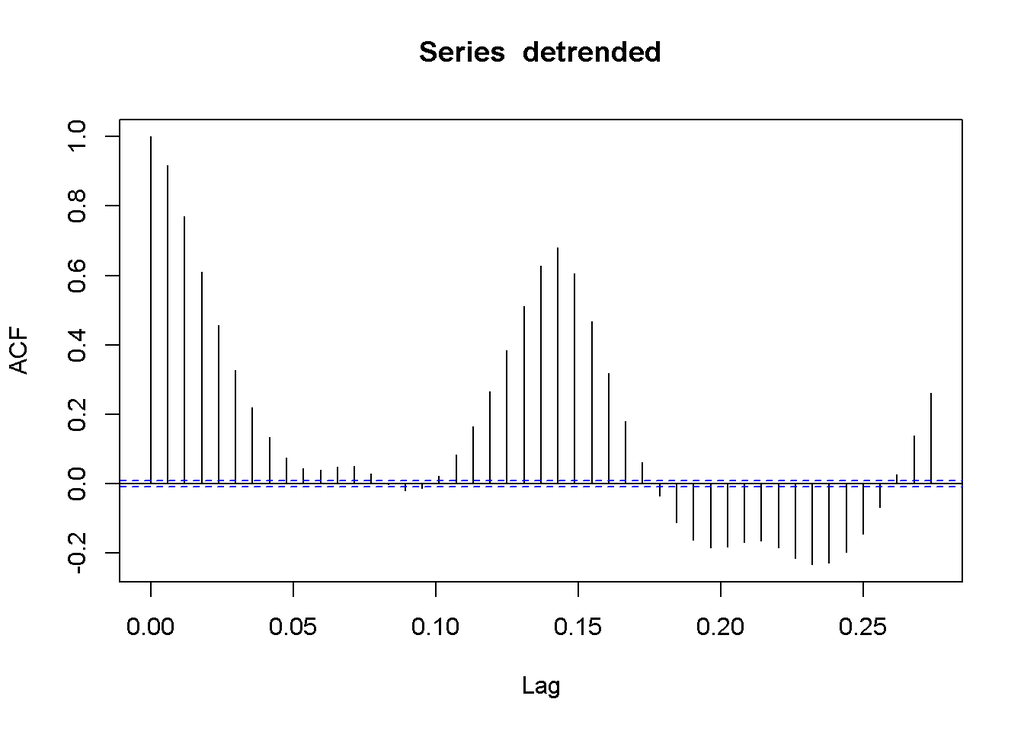

```r
acf(detrended,na.action=na.pass)
```

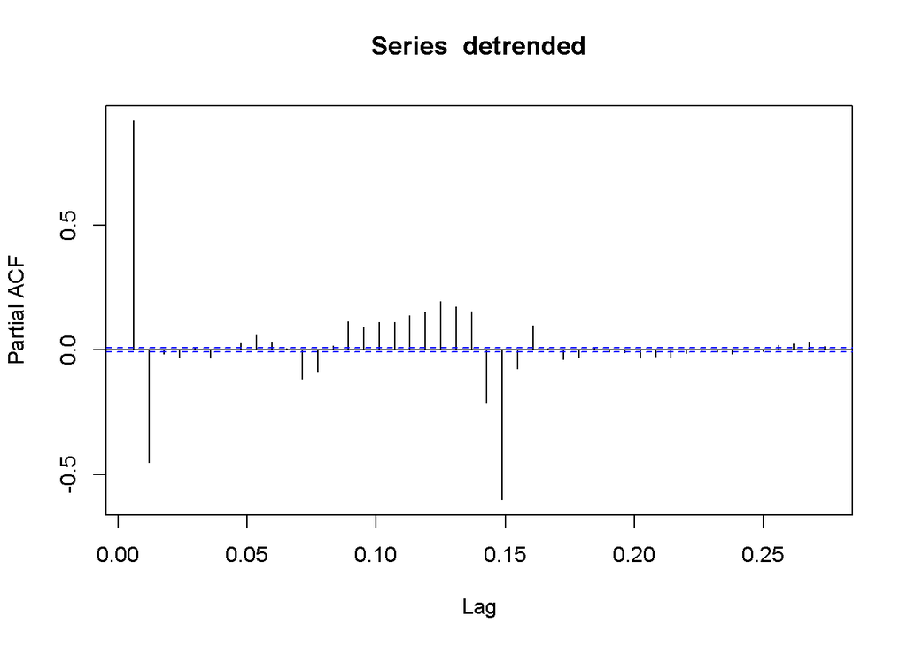

```r
pacf(detrended,na.action=na.pass)
```

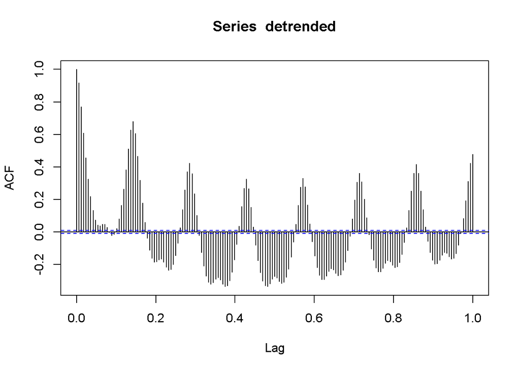

```r
acf(detrended,na.action=na.pass,168)
```

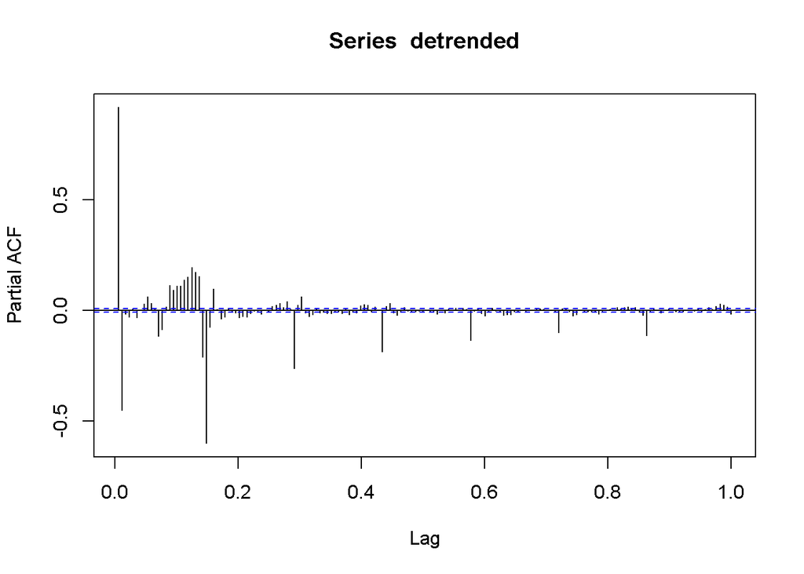

```r
pacf(detrended,na.action=na.pass,168)
```

```r
test2=ur.kpss(detrended)
summary(test2)
```

```
##
## #######################
## # KPSS Unit Root Test #
## #######################
##
## Test is of type: mu with 18 lags.
##
## Value of test-statistic is: 0.0042
##
## Critical value for a significance level of:
##                 10pct  5pct 2.5pct  1pct
## critical values 0.347 0.463  0.574 0.739
```

As mentioned before, trend and seasonality components shows some important features. For example, there are seasonal increases during the summer months and winter months. It can be related to weather temperature. When the weather temperature make a pick, electricity consumption of that day relatively high. Also, similar kind of seasonality exist in the daily usage. Electricity consumption is increases from 5-6 am to noon.

## AR Models

Now, let’s consider to autocorrelation and partial autocorrelation function in order to choose a preferable p values.

```r
ar1 = arima(detrended, order = c(1,0,0))
ar2 = arima(detrended, order = c(2,0,0))
ar3 = arima(detrended, order = c(3,0,0))
ar4 = arima(detrended, order = c(4,0,0))
ar5 = arima(detrended, order = c(5,0,0))
c(ar1=AIC(ar1), ar2=AIC(ar2), ar3=AIC(ar3), ar4=AIC(ar4), ar5=AIC(ar5))
```

```
##      ar1      ar2      ar3      ar4      ar5
## 733654.4 722906.0 722896.7 722855.1 722855.1
```

```r
min(c(ar1=AIC(ar1), ar2=AIC(ar2), ar3=AIC(ar3), ar4=AIC(ar4), ar5=AIC(ar5)))
```

```
## [1] 722855.1
```

The minimum AIC value comes from ar4, so I choose p=4 and continue with MA mdels.

#MA models

Also, we can find a preferable q value by using moving average method. As expected, ma5 is the minimum solution. We can increase the q value such as ma for 10 and it gives a better value but this option is very time consuming. So we go on with q=5

```r
ma1 = arima(detrended, order = c(0,0,1))
ma2 = arima(detrended, order = c(0,0,2))
ma3 = arima(detrended, order = c(0,0,3))
ma4 = arima(detrended, order = c(0,0,4))
ma5 = arima(detrended, order = c(0,0,5))
c(ma1=AIC(ma1), ma2=AIC(ma2), ma3=AIC(ma3), ma4=AIC(ma4), ma5=AIC(ma5))
```

```
##      ma1      ma2      ma3      ma4      ma5
## 771819.8 747445.1 734563.0 728972.5 725530.1
```

```r
min(c(ma1=AIC(ma1), ma2=AIC(ma2), ma3=AIC(ma3), ma4=AIC(ma4), ma5=AIC(ma5))
)
```

```
## [1] 725530.1
```

# ARMA Models

We have decided to optimal AR and MA values as ar=4 and m=5. Now, I try to combine these two parameter and find the optimum model.

```r
model1 = arima(detrended, order = c(4,0,5))
AIC(model1)
```

```
## [1] 722820.8
```

```r
model2 = arima(detrended, order = c(4,0,4))
AIC(model2)
```

```
## [1] 721925
```

```r
model3 = arima(detrended, order = c(3,0,4))
AIC(model3)
```

```
## [1] 722805.9
```

Finally, ARIMA(4,0,4) is better than ARIMA(4,0,5) in terms of AIC. So, I prefer to use ARIMA(4,0,4) - Model2 because of both AIC value and less complexity of model.

## Forecasting

First, prepare the transformed model than make predictions. Then get rid of NA and lags.

```r
model_fit= detrended - residuals(model2)
model_fitted_transformed <- model_fit+consumptionts_dy_dec$trend+consumptionts_dy_dec$seasonal
consumptiondata[,fitted:=model_fitted_transformed]

#consumptiondata$fitted
```

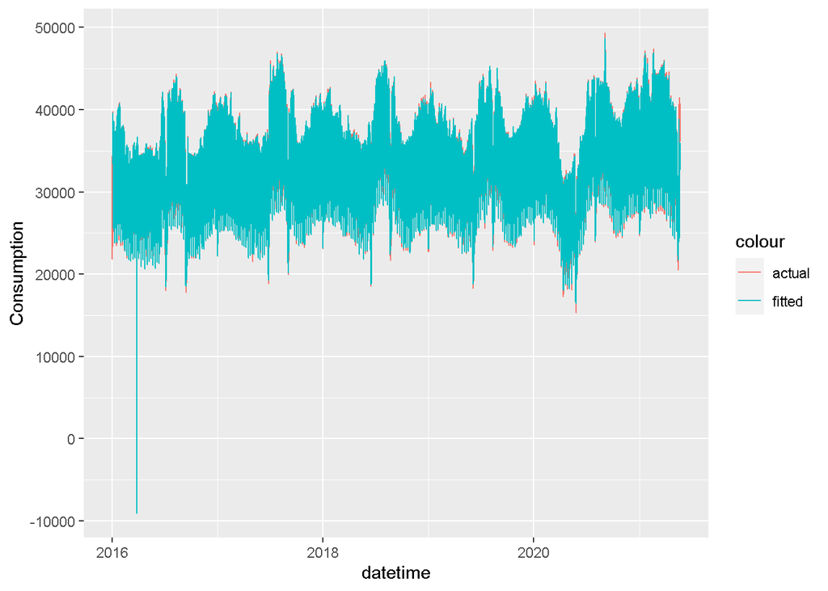

```r
Res_fit = residuals((model2))
consumptiondata[,fit_res:=Res_fit]

na_84=mean(consumptiondata$fitted[85:168])
na_84_res=mean(consumptiondata$fit_res[85:168])

consumptiondata$fitted[1:84]= na_84
consumptiondata$fit_res[1:84]=na_84_res

test_set = consumptiondata[(.N-359):.N]

res_tes=predict(model2,n.ahead = 84)$pred

#tail(consumptionts_dy_dec$trend[!is.na(consumptionts_dy_dec$trend)],84)

endt_84 = tail(consumptionts_dy_dec$trend[!is.na(consumptionts_dy_dec$trend)],84)
ends_84= tail(consumptionts_dy_dec$seasonal[!is.na(consumptionts_dy_dec$seasonal)],84)
end_comb = res_tes+endt_84+ends_84

consumptiondata$fitted[47125:47208]=end_comb

ggplot(consumptiondata , aes(x=datetime) )  +
  geom_line(aes(y=Consumption , col="actual")) +
  geom_line(aes(y=fitted , col = "fitted"))
```

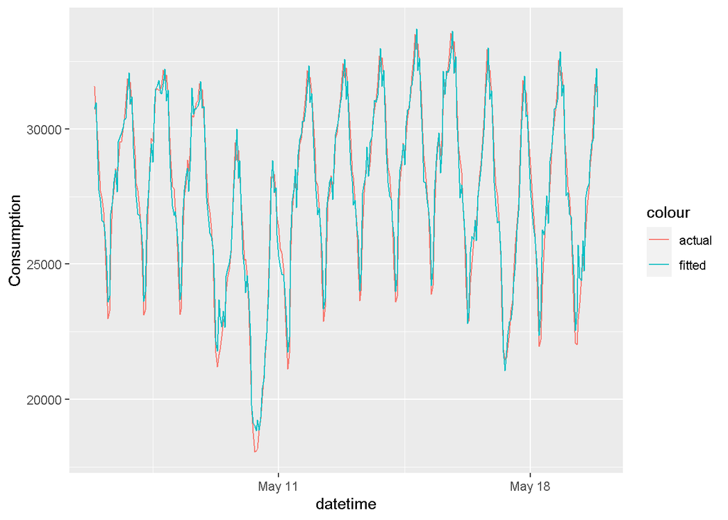

```r
#focus on 2 weeks
ggplot(consumptiondata[datetime<='2020-05-20' & datetime>='2020-05-06'] , aes(x=datetime) )  +
  geom_line(aes(y=Consumption , col="actual")) +
  geom_line(aes(y=fitted , col = "fitted"))
```

```r
actual = consumptiondata[datetime<='2020-05-20 23:00' & datetime>='2020-05-06 00:00' , Consumption ]
forecast = consumptiondata[datetime<='2020-05-20 23:00' & datetime>='2020-05-06 00:00' , fitted ]
forecast = as.numeric(forecast)
error = abs(actual - forecast)

percentage=error/consumptiondata[datetime<='2020-05-20 23:00' & datetime>='2020-05-06 00:00' , Consumption ]
wape=(sum(percentage)/360)*100
```